# Introduction to R

### R as a calculating environment

R can be used as a powerful calculator. For arithmetic calculations:

```r
(1 + 1 / 100) ^ 100
```

```
## [1] 2.704814
```

```r
17 %% 5
```

```
## [1] 2
```

```r
17 %/% 5
```

```
## [1] 3
```

`[1]` implies this is item 1 in a vector of output.

| symbol | meaning |
| --- | --- |
| + | addition |
| - | subtraction |
| * | multiplication |
| / | division |
| ^ | exponential |
| %% | modulus |
| %/% | integer division |

### Built-in function in R

R has a number of built in functions:  
`sin(x), cos(x), tan(x), exp(x), log(x), sqrt(x), floor(x), ceiling(x), round(x)`

```r
exp(1)
```

```
## [1] 2.718282
```

```r
options(digits = 16)
exp(1)
```

```
## [1] 2.718281828459045
```

```r
pi
```

```
## [1] 3.141592653589793
```

```r
sin(pi/6)
```

```
## [1] 0.4999999999999999
```

```r
floor(2.3)
```

```
## [1] 2
```

```r
ceiling(2.3)
```

```
## [1] 3
```

```r
round(2.3)
```

```
## [1] 2
```

```r
options(digits = 7)
```

### Variable

- We can assign a value to a variable and use the variable.
- For the assignment, we use command `<-`
  - Usually, this is pronounced as “gets”.
- Variable names made up of letters, numbers, . or _
  - provided it starts with a letter, or . then a letter.
  - names are case sensitive.
  - for example, * x, y, my_variable, a1, a2, .important_variable, x.input
  - wrong name: * 2016_income, .1grade, _x, y@gmail.com

To display the value of a variable `x`, we type `x`

- or `print(x)` or `show(x)`.

```r
x <- 100
x
```

```
## [1] 100
```

```r
print(x)
```

```
## [1] 100
```

```r
show(x)
```

```
## [1] 100
```

We can show the outcome of assignment by parentheses.

```r
(y <- (1 + 1 / x) ^ x)
```

```
## [1] 2.704814
```

When assigning, the right-hand side is evaluated first, then that value is placed in the variable on the left-hand side.

```r
n <- 1
n <- n + 1
n
```

```
## [1] 2
```

R allows the use of `=` for variable assignment, in common with most programming languages.

The following also works.

```r
3 -> three
three
```

```
## [1] 3
```

You can have multiple assignments.

```r
v <- w <- z <- 1
v
```

```
## [1] 1
```

```r
w
```

```
## [1] 1
```

```r
z
```

```
## [1] 1
```

### Functions

Takes one or more argument (inputs) and produces one or more outputs (return values).

```r
seq(from = 1, to = 9, by = 2)
```

```
## [1] 1 3 5 7 9
```

```r
seq(from = 1, to = 9)
```

```
## [1] 1 2 3 4 5 6 7 8 9
```

You can access the built-in help by `help(function name)` or `?function name`:

Every function has a default order for arguments.  
If you provide arguments in this order, then they do not need to be named.

```r
seq(1, 9, 2)
```

```
## [1] 1 3 5 7 9
```

```r
seq(to = 9, from = 1)
```

```
## [1] 1 2 3 4 5 6 7 8 9
```

```r
seq(by = -2, 9, 1)
```

```
## [1] 9 7 5 3 1
```

More examples:

```r
seq(1, 5, 0.5)
```

```
## [1] 1.0 1.5 2.0 2.5 3.0 3.5 4.0 4.5 5.0
```

```r
seq(0.5, 0.1, -0.1)
```

```
## [1] 0.5 0.4 0.3 0.2 0.1
```

```r
seq(1, 10, 4)
```

```
## [1] 1 5 9
```

```r
x <- 9
seq(1, x, x/3)
```

```
## [1] 1 4 7
```

We will study more about functions in Chapter 4.

### Vectors

- the basic data structure in R
  - also called atomic vector
- indexed set of variables
- i-th element of vector `x` is denoted by `x[i]`
- the types of all elements of an atomic vector should be the same
  - logical, integer, double (often called numeric), character
- three basic functions for constructing vectors
  - `seq`, `rep`, `c`
- Basic three properties:
  - Type, `typeof()`, what it is.
  - Length, `length()`, how many elements it contains.
  - Attributes, `attributes()`, additional arbitrary metadata.

```r
# short for sequence
(x <- seq(1, 20, by = 2))
```

```
##  [1]  1  3  5  7  9 11 13 15 17 19
```

```r
(x2 <- seq(1.1, 2, by = 0.1))
```

```
##  [1] 1.1 1.2 1.3 1.4 1.5 1.6 1.7 1.8 1.9 2.0
```

```r
# short for repeat
(y <- rep(3, 4))
```

```
## [1] 3 3 3 3
```

```r
# short for combine
(z <- c(y, x))
```

```
##  [1]  3  3  3  3  1  3  5  7  9 11 13 15 17 19
```

- another method for sequence

```r
(x <- 100:110)
```

```
##  [1] 100 101 102 103 104 105 106 107 108 109 110
```

```r
(y <- 110:100)
```

```
##  [1] 110 109 108 107 106 105 104 103 102 101 100
```

```r
length(x)
```

```
## [1] 11
```

- `letters, LETTERS`

```r
# the 26 lower-case letters of the Roman alphabet
letters
```

```
##  [1] "a" "b" "c" "d" "e" "f" "g" "h" "i" "j" "k" "l" "m" "n" "o" "p" "q" "r" "s"
## [20] "t" "u" "v" "w" "x" "y" "z"
```

```r
# the 26 upper-case letters of the Roman alphabet;
LETTERS
```

```
##  [1] "A" "B" "C" "D" "E" "F" "G" "H" "I" "J" "K" "L" "M" "N" "O" "P" "Q" "R" "S"
## [20] "T" "U" "V" "W" "X" "Y" "Z"
```

- `seq_along()`

`seq_along(x)` is the same as `1:length(x)`

```r
x <- letters[1:5]  # a b c d e
y <- seq_along(x)
print(y)
```

```
## [1] 1 2 3 4 5
```

- vector and index

```r
(x <- 100:110)
```

```
##  [1] 100 101 102 103 104 105 106 107 108 109 110
```

```r
# second element
x[2]
```

```
## [1] 101
```

```r
# last element
x[length(x)]
```

```
## [1] 110
```

```r
i <- c(1, 3, 2)

x[i]
```

```
## [1] 100 102 101
```

```r
x[1:5]
```

```
## [1] 100 101 102 103 104
```

minus index:

```r
j <- c(-1, -2, -3)
x[j]
```

```
## [1] 103 104 105 106 107 108 109 110
```

but you can’t mix positive and negative index, the following code is erroneous.

```r
x[c(-1, 2)]
```

empty vetor:

```r
x <- c()
```

elementwise algebraic operation:

```r
x <- c(1, 2, 3)
y <- c(4, 5, 6)
x * y
```

```
## [1]  4 10 18
```

```r
y ^ x
```

```
## [1]   4  25 216
```

with unequal length of vectors:

```r
c(1, 2, 3, 4) + c(1, 2)
```

```
## [1] 2 4 4 6
```

```r
2 * c(1, 2, 3)
```

```
## [1] 2 4 6
```

```r
(1:3)^2
```

```
## [1] 1 4 9
```

This works but with warning message:

```r
c(1, 2, 3) + c(1, 2)
```

functions taking vectors

```r
sqrt(1:3)
```

```
## [1] 1.000000 1.414214 1.732051
```

```r
mean(1:6)
```

```
## [1] 3.5
```

```r
sort(c(5, 1, 3, 4, 2))
```

```
## [1] 1 2 3 4 5
```

logical vector

```r
logi <- c(TRUE, FALSE, T, F)
typeof(logi)
```

```
## [1] "logical"
```

character vector

```r
char <- c("a", "vector", "of", "characters")
typeof(char)
```

```
## [1] "character"
```

integer vector

```r
integ <- c(1L, 2L, 3L, 4L)
typeof(integ)
```

```
## [1] "integer"
```

double vector

```r
doub <- c(1, 2, 3, 4)
typeof(doub)
```

```
## [1] "double"
```

#### `typeof()`

`typeof()` returns an (internal) object type :

- logical - logical vector
- double - double vector
- interger - interger vector
- character - character vector
- list - see Ch.5
- builtin : R built-in function
- closure : user defined function
- and so on.

Simply speaking, the objects in R are implemented via C, and the internal types mean the C level data types.

#### Coercion

If we try to combine differet types of elements in a vector, they will be coerced to the most flexible type.

- logical, integer, double, character

```r
c("a", 1)
```

```
## [1] "a" "1"
```

```r
c(TRUE, FALSE, 0)
```

```
## [1] 1 0 0
```

#### Example : mean and variance

compare computed mean and variance with built-in functions

```r
x <- c(1.2, 0.9, 0.8, 1, 1.2)

x.mean <- sum(x)/length(x)

x.mean - mean(x)
```

```
## [1] 0
```

```r
x.var <- sum((x-x.mean)^2)/(length(x)-1)
x.var - var(x)
```

```
## [1] 0
```

#### Example : simple numerical integration

- The basic problem in numerical integration is to compute an approximate solution to a definite integral.

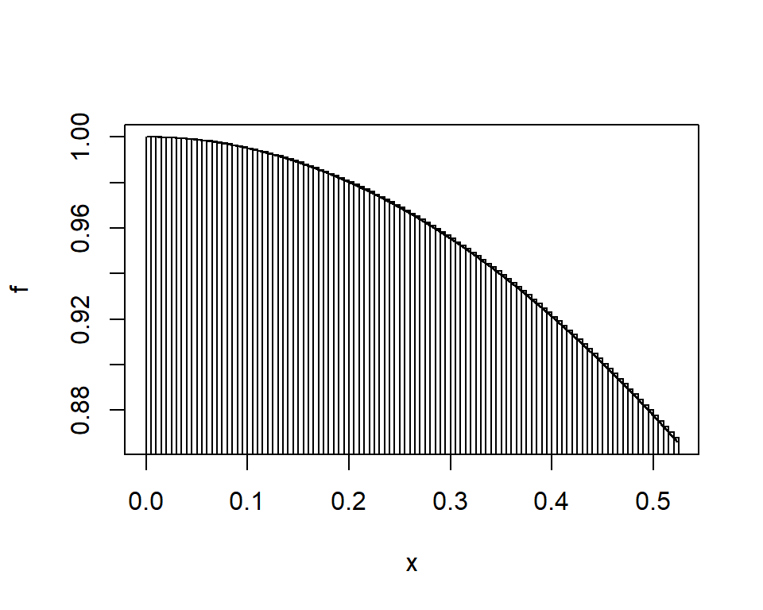

```r
dt <- 0.005
t <- seq(0, pi/6, by = dt)
ft <- cos(t)
(I <- sum(ft) * dt)
```

```
## [1] 0.5015487
```

`t` is a vector and `ft` is also a vector.

```r
I - sin(pi/6)
```

```
## [1] 0.001548651
```

Note the difference between the numerical integration and theoretical value.

#### Example : exponential limit

```r
x <- seq(10, 200, by = 10)

y <- (1 + 1/x)^x

exp(1) - y
```

```
##  [1] 0.124539368 0.064984123 0.043963053 0.033217990 0.026693799 0.022311689
##  [7] 0.019165457 0.016796888 0.014949367 0.013467999 0.012253747 0.011240338
## [13] 0.010381747 0.009645015 0.009005917 0.008446252 0.007952077 0.007512533
## [19] 0.007119034 0.006764706
```

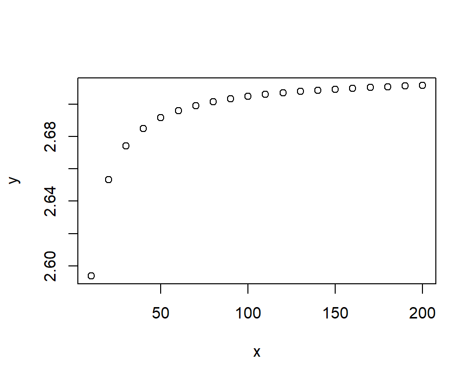

```r
plot(x, y)
```

### Missing data

in R, missing data is represented by `NA`.

```r
a <- NA   # assign NA to variable A
is.na(a)     # is it missing?
```

```
## [1] TRUE
```

```r
a <- c(11, NA, 13)
is.na(a)
```

```
## [1] FALSE  TRUE FALSE
```

```r
mean(a)
```

```
## [1] NA
```

```r
mean(a, na.rm = TRUE) #NAs can be removed
```

```
## [1] 12
```

`NA` is logical

```r
typeof(NA)
```

```
## [1] "logical"
```

and can be coerced to numeric, or integer, or charactor

```r
x <- c(NA, 10)
typeof(x[1])
```

```
## [1] "double"
```

```r
y <- c(NA, "abc")
typeof(y[1])
```

```
## [1] "character"
```

### Inf and -Inf

If a computation result is too big, R will return `Inf`.

```r
2 ^ 1024
```

```
## [1] Inf
```

```r
- 2 ^ 1024
```

```
## [1] -Inf
```

```r
1 / 0
```

```
## [1] Inf
```

### NaN

If a computation result makes little sense, then R will return `NaN`, not a number.

```r
Inf - Inf
```

```
## [1] NaN
```

```r
0 / 0
```

```
## [1] NaN
```

### Expression and assignment

Expression is a phrase of code that can be executed.

```r
seq(10, 20, by=3)
```

```
## [1] 10 13 16 19
```

```r
4
```

```
## [1] 4
```

```r
mean(c(1,2,3))
```

```
## [1] 2
```

```r
1 > 2
```

```
## [1] FALSE
```

If the evaluation of the expression is saved using `<-`, then it called an assignment.

```r
x1 <- seq(10, 20, by=3)
```

```r
x2 <- 1>2
```

A logical expression is formed using

- the comparison operators
  - `<`, `>`, `<=`, `>=`, `==`, and `!=` (not equal to)
- and the logical operators
  - `&` (and), `|` (or), and `!` (not).

The value of a logical expression is either `TRUE` or `FALSE`.

- The integers 1 and 0 can also be used as `TRUE` or `FALSE`.

```r
c(0, 0, 1, 1) | c(0, 1, 0, 1)
```

```
## [1] FALSE  TRUE  TRUE  TRUE
```

#### Example : rounding error

Many floating numbers are subject to rounding errors in digital computers.

```r
2 * 2 == 4
```

```
## [1] TRUE
```

```r
sqrt(2) * sqrt(2) == 2
```

```
## [1] FALSE
```

The solution is to use `all.equal(x,y)`, which returns TRUE if the difference between x and y is smaller than some tolerance.

```r
all.equal(sqrt(2) * sqrt(2), 2)
```

```
## [1] TRUE
```

### x[subset]

R’s subsetting operators are powerful and fast.

Subsetting is hard to learn.

We can extract a subvector using a subset as a vector of TRUE/FALSE.

```r
x <- 1:10
x%%4 == 0
```

```
##  [1] FALSE FALSE FALSE  TRUE FALSE FALSE FALSE  TRUE FALSE FALSE
```

```r
( y <- x[ x%%4==0 ] )
```

```
## [1] 4 8
```

R also provides `subset` function, which ignore `NA`.

- whereas `x[subset]` preserves `NA`.

```r
x <- c(1, NA, 3, 4)
x[x > 2]
```

```
## [1] NA  3  4
```

```r
subset(x, subset = x>2 )
```

```
## [1] 3 4
```

For the index position of TRUE elements, use `which(x)`

```r
x <- c(1, 1, 2, 3, 5, 8, 13)
which(x %% 2 == 0)
```

```
## [1] 3 6
```

Explore more about subsetting:

```r
x <- c(2.1, 4.2, 3.3, 5.4)
```

```r
x[c(TRUE,FALSE,TRUE,FALSE)]
```

```
## [1] 2.1 3.3
```

```r
x[x > 3]
```

```
## [1] 4.2 3.3 5.4
```

```r
x[order(x)]
```

```
## [1] 2.1 3.3 4.2 5.4
```

### Sequential `&&` and `||`

To evaluate `x && y`, R first evaluate `x`. If `x` is `FALSE` then R returns `FALSE` without evaluating `y`.

To evaluate `x || y`, R first evaluate `x`. If `x` is `TRUE` then R returns `TRUE` without evaluating `y`.

Sequential evalutation of `x` and `y` is useful when `y` is not always well defined.

```r
x <- 0
x == 0 || sin(1/x) == 0
```

```
## [1] TRUE
```

Note that `&&` and `||` only work on scalars, whereas `&` and `|` work on vectors elementwise.

### subsetting and assignment

Subsetting operators can be combined with assignment operator.

```r
x <- 1:5
x[c(1, 2)] <- 2:3
x
```

```
## [1] 2 3 3 4 5
```

```r
x[-1] <- 4:1
x
```

```
## [1] 2 4 3 2 1
```

```r
x[x %% 2 == 0] <- 0
x
```

```
## [1] 0 0 3 0 1
```

```r
x[which(x == max(x))] <- 100
x
```

```
## [1]   0   0 100   0   1
```

### Names

You can name a vector:

```r
(x <- c(a = 1, b = 2, c = 3))
```

```
## a b c
## 1 2 3
```

`names` function returns a charater vector:

```r
names(x)
```

```
## [1] "a" "b" "c"
```

```r
y <- 1:3
names(y) <- c("first", "second", "third")
y
```

```
##  first second  third
##      1      2      3
```

and select elements by names:

```r
y["first"]
```

```
## first
##     1
```

```r
y[c("first", "third")]
```

```
## first third
##     1     3
```

### Matrix

Matrix is created from a vector using the function matrix:

- `matrix( data, nrow =1, ncol=1, byrow=FALSE )`
  - `data` : vector of length at most `nrow*ncol`
    - if length of vector < nrow*ncol, then data is reused as many times as is needed
  - `nrow` : number of rows
  - `ncol` : number of columns
  - `byrow = TRUE` : fill the matrix up row-by-row
  - `byrow = FALSE` : fill the matrix up column-by-column, default
- `diag(x)` : create diagonal matrix
- `rbind(...)` : join matrices with rows of the same length
- `cbind(...)` : join matrices with columns of the same length

Example:

```r
(A <- matrix(1:6, nrow = 2, ncol = 3))
```

```
##      [,1] [,2] [,3]
## [1,]    1    3    5
## [2,]    2    4    6
```

```r
(A <- matrix(1:6, nrow = 2, ncol = 3, byrow = TRUE))
```

```
##      [,1] [,2] [,3]
## [1,]    1    2    3
## [2,]    4    5    6
```

```r
A[1, 3] <- 0
A
```

```
##      [,1] [,2] [,3]
## [1,]    1    2    0
## [2,]    4    5    6
```

```r
A[, 2:3]
```

```
##      [,1] [,2]
## [1,]    2    0
## [2,]    5    6
```

```r
(B <- diag(c(1, 2, 3)))
```

```
##      [,1] [,2] [,3]
## [1,]    1    0    0
## [2,]    0    2    0
## [3,]    0    0    3
```

Matrix operation

- Usual algebraic operations, including `*`, act elementwise.
- To perform matrix operation, we use `%*%`.
- `nrow(x)`, `ncol(x)`
- `det(x)` : determinant of `x`
- `t(x)` : transpose of `x`
- `solve(A, B)` : returns `x` such that `A %*% x = B`
- If `A` is invertable, the `solve(A)` is the inverse of `A`.

```r
A <- matrix(c(3, 5, 2, 3), nrow=2, ncol=2)
B <- matrix(c(1, 1, 0, 1), nrow=2, ncol=2)
```

```r
A %*% B
```

```
##      [,1] [,2]
## [1,]    5    2
## [2,]    8    3
```

```r
A.inv <- solve(A)
A %*% A.inv   # we observe rounding error
```

```
##      [,1]          [,2]
## [1,]    1 -8.881784e-16
## [2,]    0  1.000000e+00
```

```r
A^(-1)   #This is not an inverse. ^(-1) applies elementwise.
```

```
##           [,1]      [,2]
## [1,] 0.3333333 0.5000000
## [2,] 0.2000000 0.3333333
```

`cbind()` : Combine R objects by columns

`rbind()` : Combine R objects by rows

```r
(C <- cbind(A,B))
```

```
##      [,1] [,2] [,3] [,4]
## [1,]    3    2    1    0
## [2,]    5    3    1    1
```

```r
(D <- rbind(A,B))
```

```
##      [,1] [,2]
## [1,]    3    2
## [2,]    5    3
## [3,]    1    0
## [4,]    1    1
```

```r
colnames(C) <- c("a", "b", "c", "d")
C
```

```
##      a b c d
## [1,] 3 2 1 0
## [2,] 5 3 1 1
```

```r
rownames(C) <- c("first", "second")
C
```

```
##        a b c d
## first  3 2 1 0
## second 5 3 1 1
```

```r
# number of rows
nrow(C)
```

```
## [1] 2
```

```r
# number of columns
ncol(C)
```

```
## [1] 4
```

#### Subsetting of matrix

select columns:

```r
(partC1 <- C[, c(1, 2)])
```

```
##        a b
## first  3 2
## second 5 3
```

select columns by column names:

```r
(partC1 <- C[, c("a", "b")])
```

```
##        a b
## first  3 2
## second 5 3
```

`partC1` is a matrix

```r
class(partC1)
```

```
## [1] "matrix" "array"
```

When you select one column, it becomes a vector, not a matrix

```r
this_is_vector_now <- C[, "a"]
class(this_is_vector_now)
```

```
## [1] "numeric"
```

When you want to preserve matrix form:

```r
still_matrix <- C[, "a", drop = FALSE]
class(still_matrix)
```

```
## [1] "matrix" "array"
```

select rows:

```r
(partC2 <- C[1,])
```

```
## a b c d
## 3 2 1 0
```

Or, in a combined way:

```r
(partC2 <- C[1, c(2, 3)])
```

```
## b c
## 2 1
```

```r
class(partC2)
```

```
## [1] "numeric"
```

When we use a single index, R counts the index columnwise:

```r
C[1]
```

```
## [1] 3
```

```r
C[2]
```

```
## [1] 5
```

```r
C[3]
```

```
## [1] 2
```

```r
C[4]
```

```
## [1] 3
```

```r
is.vector(partC2)
```

```
## [1] TRUE
```

```r
is.matrix(partC2)
```

```
## [1] FALSE
```

```r
(Cm <- as.matrix(partC2))
```

```
##   [,1]
## b    2
## c    1
```

```r
class(Cm)
```

```
## [1] "matrix" "array"
```

```r
(Cv <- as.vector(Cm))
```

```
## [1] 2 1
```

```r
class(Cv)
```

```
## [1] "numeric"
```

### Objects and classes

R is an object oriented language.

Every object in R is a member of a class.

You can use the `class` function to determine the class of object.

```r
# numeric vector
class(c(1, 2, 3))
```

```
## [1] "numeric"
```

```r
# character vector
class(c("c", "B", "z"))
```

```
## [1] "character"
```

```r
# function
class(sin)
```

```
## [1] "function"
```

```r
class(matrix(c(1,2)))
```

```
## [1] "matrix" "array"
```

### Workspace

The objects that you create using R remain in existence until you explicitly delete them.

- `rm(x)` : remove object `x`
- `rm(list=ls())` : remove all objects

### Working directory

When you run R, it uses one of the directories on your hard drive as a working directory,

- where it looks for user-written programs and data files.

Check the working directory.

```r
getwd()
```

Change the working directory to “dir”

```r
setwd("dir")
```

`/` is for directory and file address, `.` refers current directory, `..` refers parent directory

### Writing script

We can type and evaluate all possible R expression at the prompt, it is much more convenient to write scripts,

- which simply comprise collections of R expression.
- We use the terms program and code synonymously with script.

You can use built-in editor in Rgui or Rstudio.

### Help

To find out more about an R command or function x, you can type `help(x)` or just `?x`.

If you cannot remember the exact name, then `help.search("x")`.

HTML help command : `help.start()`

### package

R provides various useful packages to help you.

https://cran.r-project.org/web/packages/

To install a package:

`install.packages("packagename")`

To access the package:

`library("packagename")`

Or use package menu.

R documentation : https://www.rdocumentation.org/